# homework 3

Collin

11/12/2020

## **Homework 3**

### Multiple Linear Regression

**1)** **a)**

```r
library(dplyr)
```

```r
library(ggplot2)
set.seed(1)
n <- 100
x1 <- runif(n)
x2 <- runif(n,10,20)
y <- 2+2*x1+0.3*x2+rnorm(n)
trueRegDF = data.frame(x1 = x1, x2 = x2, y = y)
```

B0 = 2 B1 = 2 B2 = 0.3 sigma squared is 1

**b)**

```r
cor.test(x1,x2) #.017
```

```
##
##  Pearson's product-moment correlation
##
## data:  x1 and x2
## t = 0.16863, df = 98, p-value = 0.8664
## alternative hypothesis: true correlation is not equal to 0
## 95 percent confidence interval:
##  -0.1799881  0.2127386
## sample estimates:
##        cor
## 0.01703215
```

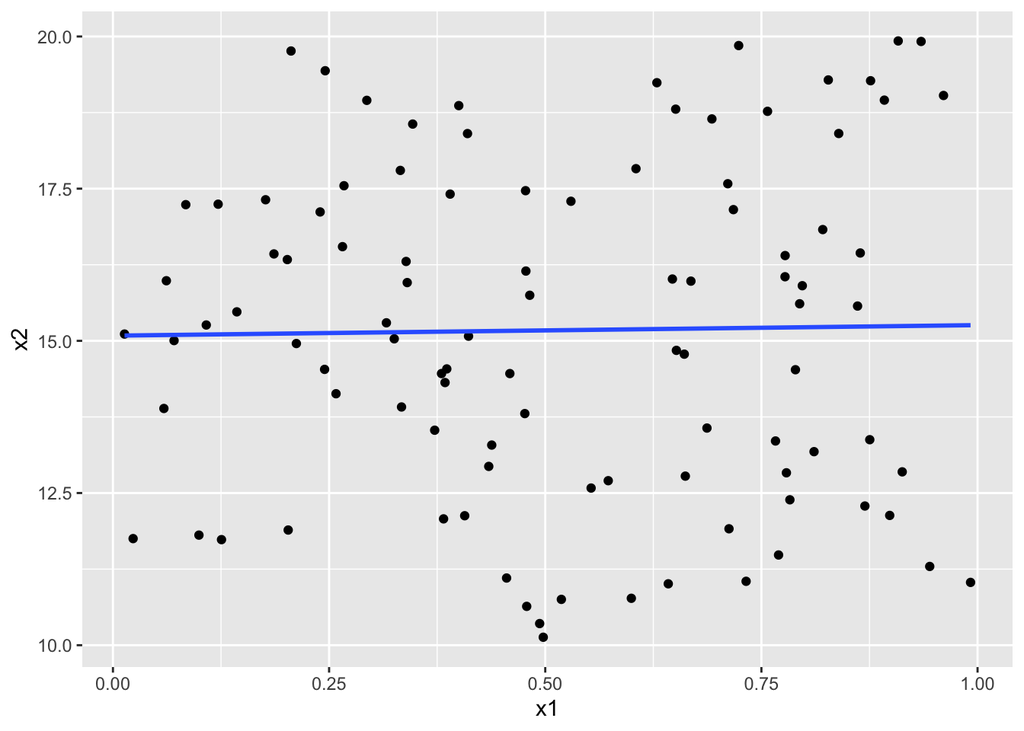

```r
ggplot(data = trueRegDF, mapping = aes(x = x1, y = x2))+
  geom_point() +
  geom_smooth(method = "lm", se = FALSE)
```

**c)**

```r
reg1 = lm(y~x1+x2, data = trueRegDF)
summary(reg1)
```

```
##
## Call:
## lm(formula = y ~ x1 + x2, data = trueRegDF)
##
## Residuals:
##     Min      1Q  Median      3Q     Max
## -1.8579 -0.6167 -0.1432  0.5352  2.3318
##
## Coefficients:
##             Estimate Std. Error t value Pr(>|t|)
## (Intercept)  1.97628    0.57973   3.409 0.000951 ***
## x1           1.93074    0.36345   5.312 6.89e-07 ***
## x2           0.30144    0.03578   8.425 3.33e-13 ***
## ---
## Signif. codes:  0 '***' 0.001 '**' 0.01 '*' 0.05 '.' 0.1 ' ' 1
##
## Residual standard error: 0.9675 on 97 degrees of freedom
## Multiple R-squared:  0.5095, Adjusted R-squared:  0.4994
## F-statistic: 50.38 on 2 and 97 DF,  p-value: 9.917e-16
```

B0,B1, and B2 are estimated to be 1.97, 1.93, and .30 respectively. These are all extremely close to the true values of the parameters. The residual standard error is .9675, which is close to the true value of sigma (1).

I can reject the null hypothesis that x1 = 0, as well as the null hypothesis that x2 = 0. Both are highly statistically significant factors (this is consistent with the true model).

**d)**

```r
reg2 = lm(y~x1, data = trueRegDF)
summary(reg2)
```

```
##
## Call:
## lm(formula = y ~ x1, data = trueRegDF)
##
## Residuals:
##      Min       1Q   Median       3Q      Max
## -2.48228 -0.97125 -0.03059  0.93666  2.78169
##
## Coefficients:
##             Estimate Std. Error t value Pr(>|t|)
## (Intercept)   6.5235     0.2770  23.548  < 2e-16 ***
## x1            1.9829     0.4758   4.168 6.64e-05 ***
## ---
## Signif. codes:  0 '***' 0.001 '**' 0.01 '*' 0.05 '.' 0.1 ' ' 1
##
## Residual standard error: 1.267 on 98 degrees of freedom
## Multiple R-squared:  0.1506, Adjusted R-squared:  0.1419
## F-statistic: 17.37 on 1 and 98 DF,  p-value: 6.638e-05
```

B0 is estimated now to be 6.5.

B1 is estimated to be about 1.98.

The estimate for B0 is now nowhere near the true value of B0. The estimate for B1 is still close to the true value of B1. Again, I would reject the null hypothesis that B1 = 0, in favor of the alternative hypothesis that it does not equal 0. This is consistent with what we know about the true model.

The residual standard error is larger than in the model with all variables. It’s also farther away from its true value (sigma is estimated to be 1.267, compared to the true value of sigma, which we know to be 1).

**e)**

```r
reg3 = lm(y~x2, data = trueRegDF)
summary(reg3)
```

```
##
## Call:
## lm(formula = y ~ x2, data = trueRegDF)
##
## Residuals:
##     Min      1Q  Median      3Q     Max
## -2.3432 -0.8776 -0.1927  0.7798  2.5804
##
## Coefficients:
##             Estimate Std. Error t value Pr(>|t|)
## (Intercept)  2.92698    0.62330   4.696 8.64e-06 ***
## x2           0.30467    0.04044   7.534 2.46e-11 ***
## ---
## Signif. codes:  0 '***' 0.001 '**' 0.01 '*' 0.05 '.' 0.1 ' ' 1
##
## Residual standard error: 1.094 on 98 degrees of freedom
## Multiple R-squared:  0.3668, Adjusted R-squared:  0.3603
## F-statistic: 56.77 on 1 and 98 DF,  p-value: 2.465e-11
```

The estimate for B0 is closer to its true value than in the previous model, but still not quite there. The estimate for B2 does appear to be close to its true value (estimated at .30467, whereas the true value is .3). The residual standard error is 1.094, which is closer to the true value of sigma. It is also an improvement in error compared to the previous model, which only included x1.

**2** **a)**

```r
set.seed(1)
n <- 100
x1 <- runif(n)
x2 <- 0.5*x1+rnorm(n,0,.01)
y <- 2+2*x1+0.3*x2+rnorm(n)
trueRegDF2 = data.frame(x1 = x1, x2 = x2, y = y)
```

**(repeating)b)**

```r
cor.test(x1,x2)
```

```
##
##  Pearson's product-moment correlation
##
## data:  x1 and x2
## t = 142.34, df = 98, p-value < 2.2e-16
## alternative hypothesis: true correlation is not equal to 0
## 95 percent confidence interval:
##  0.9964145 0.9983809
## sample estimates:
##       cor
## 0.9975904
```

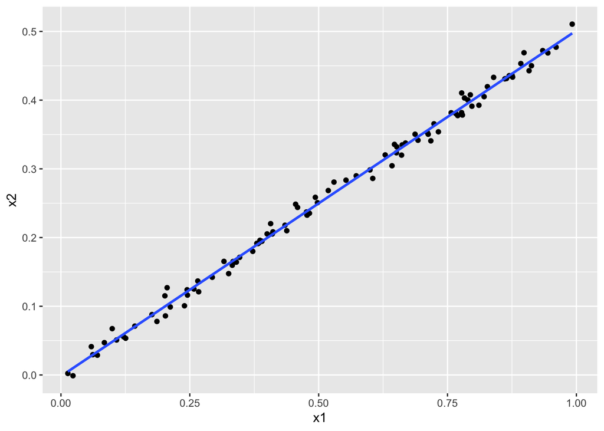

```r
ggplot(data = trueRegDF2, mapping = aes(x = x1, y = x2))+
  geom_point() +
  geom_smooth(method = "lm", se = FALSE)
```

**(repeating)c)**

```r
reg4 = lm(y~x1+x2, data = trueRegDF2)
summary(reg4)
```

```
##
## Call:
## lm(formula = y ~ x1 + x2, data = trueRegDF2)
##
## Residuals:
##     Min      1Q  Median      3Q     Max
## -2.8311 -0.7273 -0.0537  0.6338  2.3359
##
## Coefficients:
##             Estimate Std. Error t value Pr(>|t|)
## (Intercept)   2.1305     0.2319   9.188 7.61e-15 ***
## x1           -1.7540     5.7178  -0.307    0.760
## x2            7.3967    11.3372   0.652    0.516
## ---
## Signif. codes:  0 '***' 0.001 '**' 0.01 '*' 0.05 '.' 0.1 ' ' 1
##
## Residual standard error: 1.056 on 97 degrees of freedom
## Multiple R-squared:  0.2051, Adjusted R-squared:  0.1887
## F-statistic: 12.51 on 2 and 97 DF,  p-value: 1.465e-05
```

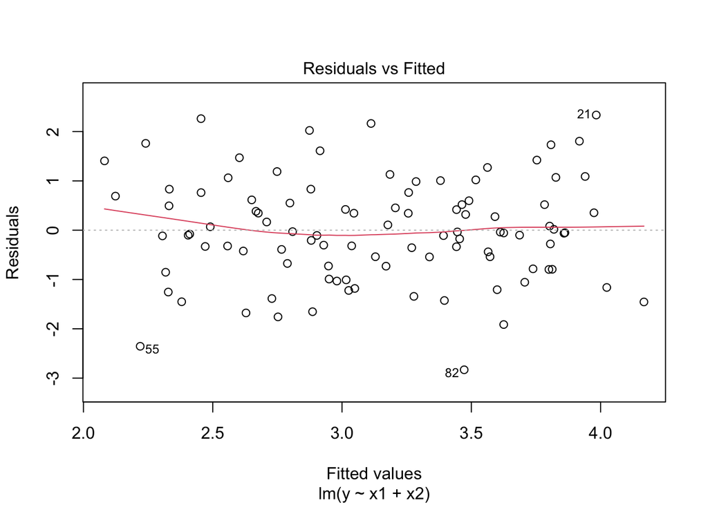

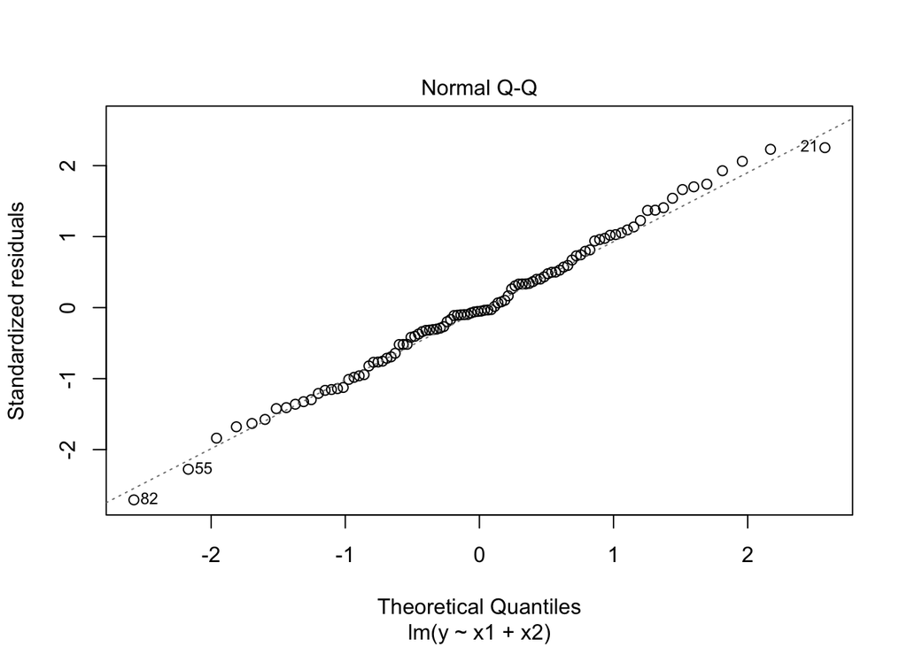

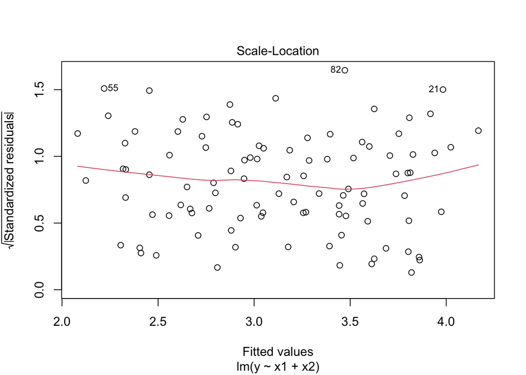

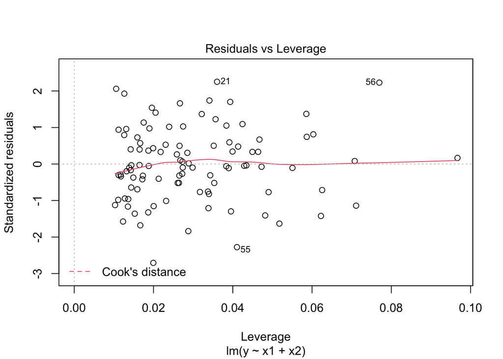

```r
plot(reg4)
```

**(repeating)d)**

```r
reg5 = lm(y~x1, data = trueRegDF2)
summary(reg5)
```

```
##
## Call:
## lm(formula = y ~ x1, data = trueRegDF2)
##
## Residuals:
##      Min       1Q   Median       3Q      Max
## -2.87789 -0.68357 -0.07517  0.61429  2.40388
##
## Coefficients:
##             Estimate Std. Error t value Pr(>|t|)
## (Intercept)   2.1172     0.2303   9.193 6.83e-15 ***
## x1            1.9675     0.3955   4.974 2.79e-06 ***
## ---
## Signif. codes:  0 '***' 0.001 '**' 0.01 '*' 0.05 '.' 0.1 ' ' 1
##
## Residual standard error: 1.053 on 98 degrees of freedom
## Multiple R-squared:  0.2016, Adjusted R-squared:  0.1934
## F-statistic: 24.74 on 1 and 98 DF,  p-value: 2.795e-06
```

B0 and B1 are estimated to be 2.1172 and 1.9675 respectively. B0 is closer to its true value (2), and I can reject the null hypothesis that B1 = 0, in favor of the alternative hypothesis that it does not equal 0 at the %5 sig. level. The residual standard error, s, is close to 1, which is close to our value of sigma/ sigma-squared.

**(repeating)e)**

```r
reg6 = lm(y~x2, data = trueRegDF2)
summary(reg6)
```

```
##
## Call:
## lm(formula = y ~ x2, data = trueRegDF2)
##
## Residuals:
##      Min       1Q   Median       3Q      Max
## -2.85470 -0.68465 -0.06898  0.60983  2.34499
##
## Coefficients:
##             Estimate Std. Error t value Pr(>|t|)
## (Intercept)   2.1199     0.2282   9.288 4.24e-15 ***
## x2            3.9273     0.7829   5.016 2.35e-06 ***
## ---
## Signif. codes:  0 '***' 0.001 '**' 0.01 '*' 0.05 '.' 0.1 ' ' 1
##
## Residual standard error: 1.051 on 98 degrees of freedom
## Multiple R-squared:  0.2043, Adjusted R-squared:  0.1962
## F-statistic: 25.16 on 1 and 98 DF,  p-value: 2.35e-06
```

B0 and B2 are estimated to be 2.1199 and 3.9273 respectively. Again, B0 is relatively close to its true value of 2. At the 5% significance level we reject the null hypothesis that B2 = 0 in favor of the alternative hypothesis that it does not equal 0. Similarly to the previous model, the residual standard error is 1.051, which is close to our value of sigma/sigma-squared.

**3** *What effect does this new observation have on the each of the models? In each model, is this observation an outlier? A high-leverage point?*

```r
x1 <- c(x1, 0.1)
x2 <- c(x2, 0.8)
y <- c(y, 6)

#now re-fitting
newRegDF = data.frame(x1 = x1, x2 = x2, y = y)

#repeating c)
fit1 = lm(y~x1+x2, data = newRegDF)
summary(fit1)
```

```
##
## Call:
## lm(formula = y ~ x1 + x2, data = newRegDF)
##
## Residuals:
##      Min       1Q   Median       3Q      Max
## -2.84668 -0.67731 -0.05031  0.58942  2.34440
##
## Coefficients:
##             Estimate Std. Error t value Pr(>|t|)
## (Intercept)   2.1250     0.2294   9.265 4.77e-15 ***
## x1           -0.5183     0.7578  -0.684 0.495630
## x2            4.9440     1.4114   3.503 0.000695 ***
## ---
## Signif. codes:  0 '***' 0.001 '**' 0.01 '*' 0.05 '.' 0.1 ' ' 1
##
## Residual standard error: 1.051 on 98 degrees of freedom
## Multiple R-squared:  0.2495, Adjusted R-squared:  0.2341
## F-statistic: 16.29 on 2 and 98 DF,  p-value: 7.82e-07
```

```r
which.max(hatvalues(fit1)) #confirms my suspicion that 101st observation has high leverage
```

```
## 101
## 101
```

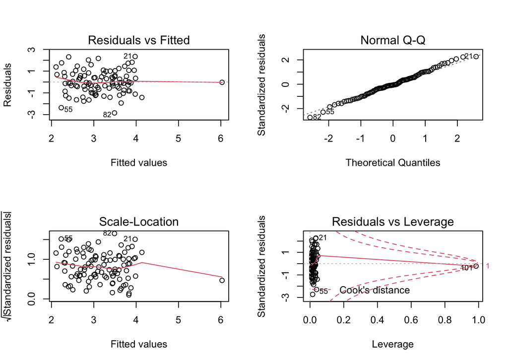

```r
#it has the greatest leverage actually

par(mfrow = c(2,2))
plot(fit1)
```

```r
library(car)
```

```
##        StudRes        Hat      CookD
## 27   0.6663058 0.04616784 0.00720385
## 55  -2.3481937 0.03870706 0.07074957
## 82  -2.8250944 0.01539361 0.03882730
## 101 -0.2180572 0.98487228 1.04199917
```

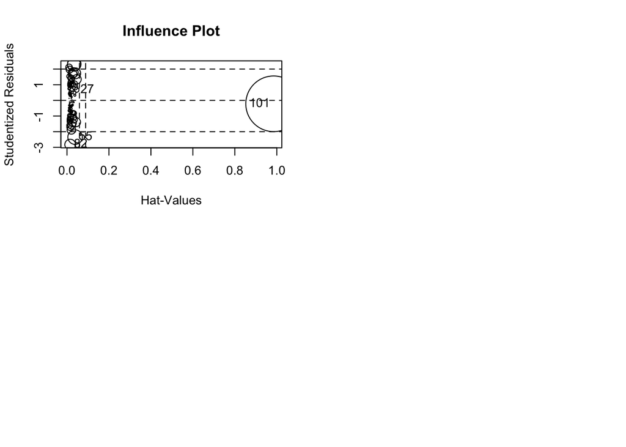

```r
influencePlot(fit1, id = "identify", main = 'Influence Plot')
```

```r
#repeating d)
 fit2 = lm(y~x1, data = newRegDF)
summary(fit2)
```

```
##
## Call:
## lm(formula = y ~ x1, data = newRegDF)
##
## Residuals:
##     Min      1Q  Median      3Q     Max
## -2.8726 -0.6826 -0.0747  0.5774  3.5626
##
## Coefficients:
##             Estimate Std. Error t value Pr(>|t|)
## (Intercept)   2.2616     0.2385   9.481 1.48e-15 ***
## x1            1.7575     0.4116   4.270 4.50e-05 ***
## ---
## Signif. codes:  0 '***' 0.001 '**' 0.01 '*' 0.05 '.' 0.1 ' ' 1
##
## Residual standard error: 1.109 on 99 degrees of freedom
## Multiple R-squared:  0.1555, Adjusted R-squared:  0.147
## F-statistic: 18.23 on 1 and 99 DF,  p-value: 4.498e-05
```

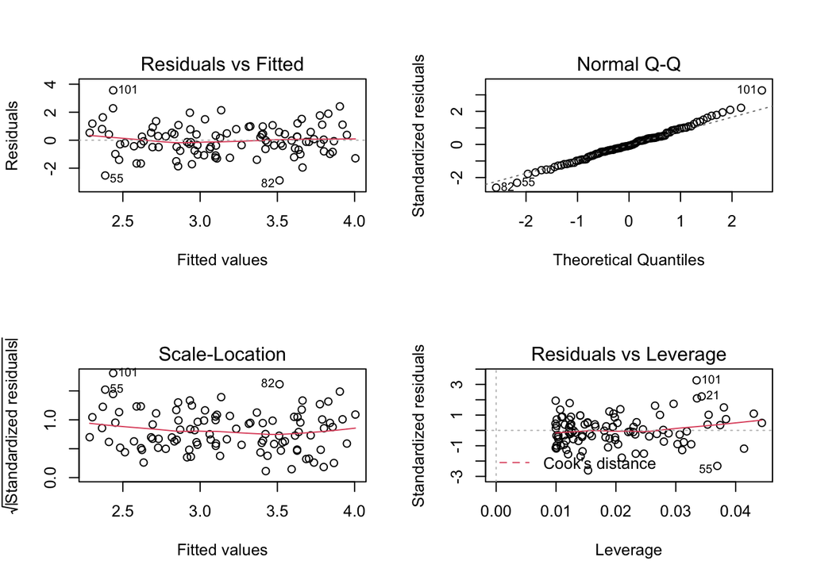

```r
par(mfrow = c(2,2))
plot(fit2)
```

```r
which.max(hatvalues(fit2))
```

```
## 27
## 27
```

Now that x2 is no longer included in the model, the diagnostic plots all look pretty standard. Looking at the normal qqplot, it appears it may still have a large residual(potential outlier). Based on the diagnostic plots, it doesn’t look like it is highly influential.

I also do not think it is a high leverage point, as when i calculate the hatvalues (leverage points) of fit2, and then find the largest, it isn’t that 101st observation anymore.

```r
fit3 = lm(y~x2,data =newRegDF)
summary(fit3)
```

```
##
## Call:
## lm(formula = y ~ x2, data = newRegDF)
##
## Residuals:
##      Min       1Q   Median       3Q      Max
## -2.87832 -0.66757 -0.06731  0.62962  2.36205
##
## Coefficients:
##             Estimate Std. Error t value Pr(>|t|)
## (Intercept)   2.0773     0.2179   9.532 1.15e-15 ***
## x2            4.1164     0.7245   5.681 1.34e-07 ***
## ---
## Signif. codes:  0 '***' 0.001 '**' 0.01 '*' 0.05 '.' 0.1 ' ' 1
##
## Residual standard error: 1.048 on 99 degrees of freedom
## Multiple R-squared:  0.2459, Adjusted R-squared:  0.2383
## F-statistic: 32.28 on 1 and 99 DF,  p-value: 1.345e-07
```

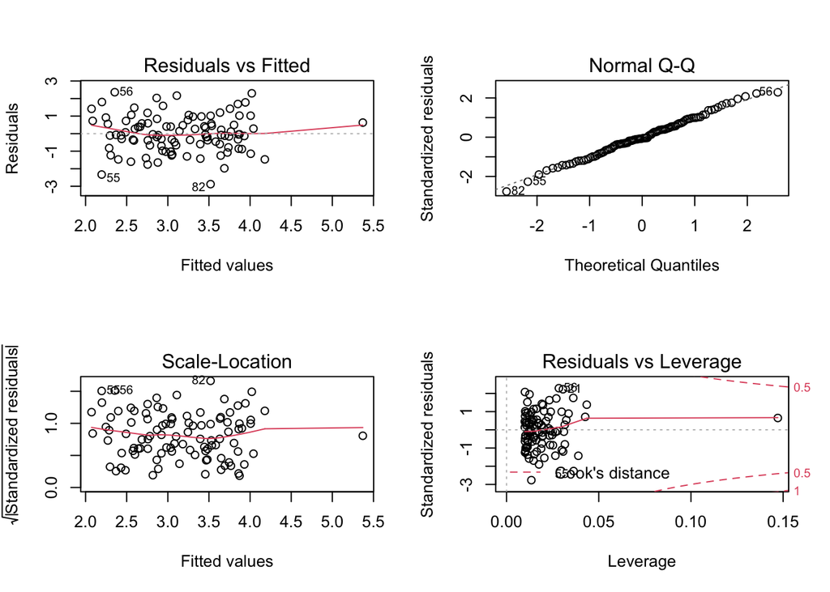

```r
par(mfrow = c(2,2))
plot(fit3)
```

```r
which.max(hatvalues(fit3))
```

```
## 101
## 101
```

Unsurprisingly, the 101st observation has reappeared as potentially concerning, as seen in the diagnostic plots, but again it does not appear to be influential (since it doesn’t cross the dashed line representing Cook’s distance.)

It is a high leverage point, but it is not an outlier based on the residuals vs leverage and normal qqplot.